# STT5510 - Démonstration #1

Alexandre LeBlanc

# Statistiques descriptives et visualisations de base

## Base de données - Devoir #1 (H2019)

La base de données utilisée par la présente démonstration est disponible au répertoire Github d’Arthur Charpentier: https://github.com/freakonometrics/STT5100/blob/master/archives/H2019/code/STT5100-H2019-devoir1.md.

Pour télécharger la base de données effectuez le code suivant:

```r
code_permanent = "ABCD12345678"
loc_fichier = paste("http://freakonometrics.free.fr/",code_permanent,".RData",sep="")
download.file(loc_fichier, "base_devoir_1.RData")
load("base_devoir_1.RData")
dim(database)
```

## Survol de RMarkdown

En général, un langage dit mardown est un example de langage markup (e.g. HTML, **Hypertext Markup Language**) qui a pour objectif d’organiser et de mettre en évidence la priorité des éléments d’un texte.

[figure not shown]

```r
knitr::include_graphics(c("https://miro.medium.com/max/5120/1*l4xICbIIYlz1OTymWCoUTw.jpeg", "https://bookdown.org/yihui/rmarkdown/images/hex-rmarkdown.png"))
```

Ceci est le but d’un langage de markup et il suffit de se prévaloir d’autres langages, dont CSS (**Cascading Style Sheets**) et JS (**JavaScript**) dans le cas du HTML pour enrichir l’aspect visuel et l’interactivité d’un fichier `.html`. *L’emphase de ce cours sera uniquement sur la rédaction du contenu et des augmentations que vous pouvez y apporter par le biais du langage de markup et R pour parvenir à compléter les devoirs et les projets*.

Un autre exemple de *langage* de markup est $\LaTeX$ qui crée un fichier `.pdf`.

Assurez-vous de télécharger la librarie `knitr` qui permet d’interpréter plusieurs langages de programmation (e.g. Python, SQL, CSS, JS, etc.). Selon la référence, [R Markdown: The Definitive Guide](https://bookdown.org/yihui/rmarkdown/installation.html), il faut installer les libraries `rmarkdown` et `tiny_tex` si vous n’aviez pas installé $\LaTeX$ et vous voulez générer un sortie `.pdf`.

## Syntaxe RMarkdown

La syntaxe de RMarkdown repose sur le texte avec annotations (i.e. markup) et la librarie `knitr` qui sert d’interpreteur de code et de générateur de fichier markdown qui est ensuite saisi et affiché.

Elle débute avec un encadrement qui comprend les métadonnées (e.g. titre, nom de l’auteur, date et les paramètres du fichier) `.Rmd`. C’est à l’intérieur de ces paramètres que nous pouvons spécifier un jeu de données qui sera appelé par notre code R. Ce bloc est rédigé en YAML, ou encore **YAML Ain’t Markup Language**.

Pour encadrer le code R dans le fichier `.Rmd`, la syntaxe de RMarkdown demande d’insérer le code ci-bas à l’intérieur de `` ```{r} ... ``` ``:

```r
paste("Hello", "World!")
```

```
## [1] "Hello World!"
```

Il y a ensuite plusieurs options qui peuvent s’exercer:

- `include = FALSE` pour eviter que le code et ses résultats n’apparaissent au fichier final.
- `echo = FALSE` pour éviter que le code appraisse au fichier final, **mais pas les résultats de ce dernier**.
- `message = FALSE` pour éviter que les messages R (e.g. installation de libraries) apparaissent au fichier final.
- `warning = FALSE` pour éviter que les avertissements R apparaissent au fichier final.
- `error = FALSE` pour éviter que les messages **d’erreur** R apparaissent au fichier final.
- `results = "hide"` pour cacher les résultats du code exécuté.
- `fig.cap = ...` pour ajouter un commentaire à une image.
- parmi tant d’autres sont disponibles au https://www.rstudio.com/wp-content/uploads/2015/03/rmarkdown-reference.pdf

Ces options peuvent être définies **globalement** à l’aide de l’énoncé `knitr::opts_chunk$set` à l’intérieur d’un *chunk* R.

Comme HTML, il y a certaines annotations qui permettent de modifier le style de la sortie du fichier `.Rmd`:

- Caractères:
  - `*italique*` affiche *italique*.
  - `**gras**` affiche **gras**.
  - `exposant^2^` affiche exposant<sup>2</sup>.
  - `[Site web du cours](https://github.com/freakonometrics/STT5100)` affiche Site web du  
    cours.
  - `<!-- regular html comment -->` permet d’écrire le commentaire `regular html comment`.

Il y a également la possibilité d’utiliser le langage $\LaTeX$ afin d’illustrer des équations mathématiques. Par exemple,

$$\text{Soient } X_{1},\,\ldots\,,X_{n}, n \in \mathbb{N} \text{ des } v.a. i.i.d \text{ telles que } E(X_{i}) = \mu, \text{Var}(X_{i}) = \sigma^{2} \in \mathbb{R}^{+}. \text{Soient } \overline{X}_{n} = \frac{X_{1} +\,\ldots\,+ X_{n}}{n} \text{ et } Z \sim \mathcal{N}(0, 1).\\
\text{Il s'ensuit que} \lim_{n \to \infty} \text{Pr}\left(\frac{\overline{X}_{n} - \mu}{\sigma/\sqrt{n}} \leq z\right) = \text{Pr}(Z \leq z),\,\forall z \in \mathbb{R}$$
.

On peut aussi utiliser $\LaTeX$ pour afficher des images ou des tableaux à l’aide des environments, `table` `tabular`, `longtable` parmi tant d’autres. Par contre, il existe des libraries R qui aident à batîr des tableaux de manière beaucoup plus efficace.

## Tableaux

Pour créer un tableau à l’aide de RMarkdown, on peut utiliser la fonction `kable` de la librarie `knitr`:

```r
library(knitr)
kable(head(database)[, 1:10], caption="Un tableau `knitr`.")
```

Un tableau `knitr`.

|  | Zone | Surface_Lot | Rue | Forme | Utilities | Configuration | Proxim_1 | Proxim_2 | Logement | Style |
| --- | --- | --- | --- | --- | --- | --- | --- | --- | --- | --- |
| 778 | RL | 15400 | Pave | Reg | AllPub | Inside | Norm | Norm | 1Fam | SLvl |
| 1090 | RL | 8010 | Pave | IR1 | AllPub | Inside | Norm | Norm | 1Fam | 2Story |
| 1678 | RM | 2058 | Pave | Reg | AllPub | Inside | Norm | Norm | Twnhs | 2Story |
| 2659 | RM | 9600 | Pave | Reg | AllPub | Inside | Norm | Norm | 1Fam | 2Story |
| 591 | RL | 9650 | Pave | Reg | AllPub | Inside | Norm | Norm | 1Fam | 1Story |
| 2628 | RL | 8512 | Pave | Reg | AllPub | Corner | Norm | Norm | Duplex | 1Story |

On peut en quelques lignes obtenir une table de probabilité de $v.a.\ \mathcal{N}(0, 1)$. La librarie `kableExtra` permet d’illustrer des tableaux plus complexes en HTML à l’aide de l’opérateur de *piping*, `%>%, qui permet d’appliquer une composition de fonctions R et knitr.

```r
library(knitr)
library(kableExtra)

u = seq(0, 3.09, by = 0.01)
p = pnorm(u)
tableNormale = matrix(p, ncol = 10, byrow = TRUE)
rownames(tableNormale) <- seq(from = 0, to = 3 , by = 0.1)
colnames(tableNormale) <- seq(from = 0, to = 0.09, by = 0.01)

tableNormale %>% kable() %>% kable_styling(bootstrap_options = c("striped", "bordered"), position = "center", font_size = 13) %>%
                             column_spec(1, width = "100px", background = "#1FC1D6") %>%
                             scroll_box(width = "100%", height = "500px")
```

|  | 0 | 0.01 | 0.02 | 0.03 | 0.04 | 0.05 | 0.06 | 0.07 | 0.08 | 0.09 |
| --- | --- | --- | --- | --- | --- | --- | --- | --- | --- | --- |
| 0 | 0.5000000 | 0.5039894 | 0.5079783 | 0.5119665 | 0.5159534 | 0.5199388 | 0.5239222 | 0.5279032 | 0.5318814 | 0.5358564 |
| 0.1 | 0.5398278 | 0.5437953 | 0.5477584 | 0.5517168 | 0.5556700 | 0.5596177 | 0.5635595 | 0.5674949 | 0.5714237 | 0.5753454 |
| 0.2 | 0.5792597 | 0.5831662 | 0.5870644 | 0.5909541 | 0.5948349 | 0.5987063 | 0.6025681 | 0.6064199 | 0.6102612 | 0.6140919 |
| 0.3 | 0.6179114 | 0.6217195 | 0.6255158 | 0.6293000 | 0.6330717 | 0.6368307 | 0.6405764 | 0.6443088 | 0.6480273 | 0.6517317 |
| 0.4 | 0.6554217 | 0.6590970 | 0.6627573 | 0.6664022 | 0.6700314 | 0.6736448 | 0.6772419 | 0.6808225 | 0.6843863 | 0.6879331 |
| 0.5 | 0.6914625 | 0.6949743 | 0.6984682 | 0.7019440 | 0.7054015 | 0.7088403 | 0.7122603 | 0.7156612 | 0.7190427 | 0.7224047 |
| 0.6 | 0.7257469 | 0.7290691 | 0.7323711 | 0.7356527 | 0.7389137 | 0.7421539 | 0.7453731 | 0.7485711 | 0.7517478 | 0.7549029 |
| 0.7 | 0.7580363 | 0.7611479 | 0.7642375 | 0.7673049 | 0.7703500 | 0.7733726 | 0.7763727 | 0.7793501 | 0.7823046 | 0.7852361 |
| 0.8 | 0.7881446 | 0.7910299 | 0.7938919 | 0.7967306 | 0.7995458 | 0.8023375 | 0.8051055 | 0.8078498 | 0.8105703 | 0.8132671 |
| 0.9 | 0.8159399 | 0.8185887 | 0.8212136 | 0.8238145 | 0.8263912 | 0.8289439 | 0.8314724 | 0.8339768 | 0.8364569 | 0.8389129 |
| 1 | 0.8413447 | 0.8437524 | 0.8461358 | 0.8484950 | 0.8508300 | 0.8531409 | 0.8554277 | 0.8576903 | 0.8599289 | 0.8621434 |
| 1.1 | 0.8643339 | 0.8665005 | 0.8686431 | 0.8707619 | 0.8728568 | 0.8749281 | 0.8769756 | 0.8789995 | 0.8809999 | 0.8829768 |
| 1.2 | 0.8849303 | 0.8868606 | 0.8887676 | 0.8906514 | 0.8925123 | 0.8943502 | 0.8961653 | 0.8979577 | 0.8997274 | 0.9014747 |
| 1.3 | 0.9031995 | 0.9049021 | 0.9065825 | 0.9082409 | 0.9098773 | 0.9114920 | 0.9130850 | 0.9146565 | 0.9162067 | 0.9177356 |
| 1.4 | 0.9192433 | 0.9207302 | 0.9221962 | 0.9236415 | 0.9250663 | 0.9264707 | 0.9278550 | 0.9292191 | 0.9305634 | 0.9318879 |
| 1.5 | 0.9331928 | 0.9344783 | 0.9357445 | 0.9369916 | 0.9382198 | 0.9394292 | 0.9406201 | 0.9417924 | 0.9429466 | 0.9440826 |
| 1.6 | 0.9452007 | 0.9463011 | 0.9473839 | 0.9484493 | 0.9494974 | 0.9505285 | 0.9515428 | 0.9525403 | 0.9535213 | 0.9544860 |
| 1.7 | 0.9554345 | 0.9563671 | 0.9572838 | 0.9581849 | 0.9590705 | 0.9599408 | 0.9607961 | 0.9616364 | 0.9624620 | 0.9632730 |
| 1.8 | 0.9640697 | 0.9648521 | 0.9656205 | 0.9663750 | 0.9671159 | 0.9678432 | 0.9685572 | 0.9692581 | 0.9699460 | 0.9706210 |
| 1.9 | 0.9712834 | 0.9719334 | 0.9725711 | 0.9731966 | 0.9738102 | 0.9744119 | 0.9750021 | 0.9755808 | 0.9761482 | 0.9767045 |
| 2 | 0.9772499 | 0.9777844 | 0.9783083 | 0.9788217 | 0.9793248 | 0.9798178 | 0.9803007 | 0.9807738 | 0.9812372 | 0.9816911 |
| 2.1 | 0.9821356 | 0.9825708 | 0.9829970 | 0.9834142 | 0.9838226 | 0.9842224 | 0.9846137 | 0.9849966 | 0.9853713 | 0.9857379 |
| 2.2 | 0.9860966 | 0.9864474 | 0.9867906 | 0.9871263 | 0.9874545 | 0.9877755 | 0.9880894 | 0.9883962 | 0.9886962 | 0.9889893 |
| 2.3 | 0.9892759 | 0.9895559 | 0.9898296 | 0.9900969 | 0.9903581 | 0.9906133 | 0.9908625 | 0.9911060 | 0.9913437 | 0.9915758 |
| 2.4 | 0.9918025 | 0.9920237 | 0.9922397 | 0.9924506 | 0.9926564 | 0.9928572 | 0.9930531 | 0.9932443 | 0.9934309 | 0.9936128 |
| 2.5 | 0.9937903 | 0.9939634 | 0.9941323 | 0.9942969 | 0.9944574 | 0.9946139 | 0.9947664 | 0.9949151 | 0.9950600 | 0.9952012 |
| 2.6 | 0.9953388 | 0.9954729 | 0.9956035 | 0.9957308 | 0.9958547 | 0.9959754 | 0.9960930 | 0.9962074 | 0.9963189 | 0.9964274 |
| 2.7 | 0.9965330 | 0.9966358 | 0.9967359 | 0.9968333 | 0.9969280 | 0.9970202 | 0.9971099 | 0.9971972 | 0.9972821 | 0.9973646 |
| 2.8 | 0.9974449 | 0.9975229 | 0.9975988 | 0.9976726 | 0.9977443 | 0.9978140 | 0.9978818 | 0.9979476 | 0.9980116 | 0.9980738 |
| 2.9 | 0.9981342 | 0.9981929 | 0.9982498 | 0.9983052 | 0.9983589 | 0.9984111 | 0.9984618 | 0.9985110 | 0.9985588 | 0.9986051 |
| 3 | 0.9986501 | 0.9986938 | 0.9987361 | 0.9987772 | 0.9988171 | 0.9988558 | 0.9988933 | 0.9989297 | 0.9989650 | 0.9989992 |

La documentation de `kableExtra` est disponible au [Create Awesome HTML Table with knitr::kable and kableExtra](https://haozhu233.github.io/kableExtra/awesome_table_in_html.html#column__row_specification).

La librarie `pander` qui permet de produire automatiquement un tableau des esitmateurs et statistiques du test d’un modèle linéaire:

```r
library(pander)

n = 1000
x = rnorm(n)
y = 2 * x + rnorm(n)
fit <- lm(y ~ x)
panderOptions("digits", 2)
pander(fit)
```

Fitting linear model: y ~ x

|  | Estimate | Std. Error | t value | Pr(>\|t\|) |
| --- | --- | --- | --- | --- |
| **(Intercept)** | -0.033 | 0.031 | -1 | 0.3 |
| **x** | 2 | 0.031 | 64 | 0 |

## Graphiques

Pour afficher des graphiques, comme tout autre code R, il suffit de glisser le code adapté à l’intérieur d’un bloc `` ```{r} ... ``` ``:

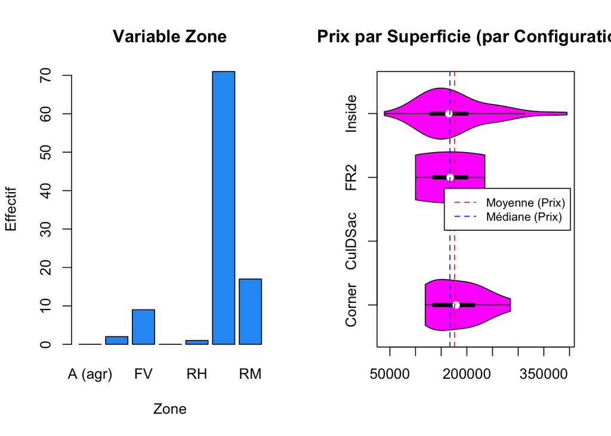

Graphiques à l’aide de R de base.

```r
library(ggplot2)
library(vioplot)
library(gridExtra)
attach(database)

par(mfrow = c(1, 2))
zone_num = table(Zone)
barplot(height = zone_num, beside = TRUE, col = "#2A9BF3", xlab = "Zone", ylab = "Effectif", main = "Variable Zone")

vioplot(Prix ~ droplevels(Configuration), horizontal = TRUE, col = "magenta", xlab = "Prix ($)", ylab = "Configuration")
title("Prix par Superficie (par Configuration)")
abline(v = mean(Prix), col = "red", lty = 2)
abline(v = median(Prix), col = "blue", lty = 2)
legend("right", inset = .02, c("Moyenne (Prix)", "Médiane (Prix)"), lty = c(2, 2), col = c("red", "blue"), cex = 0.8)
```

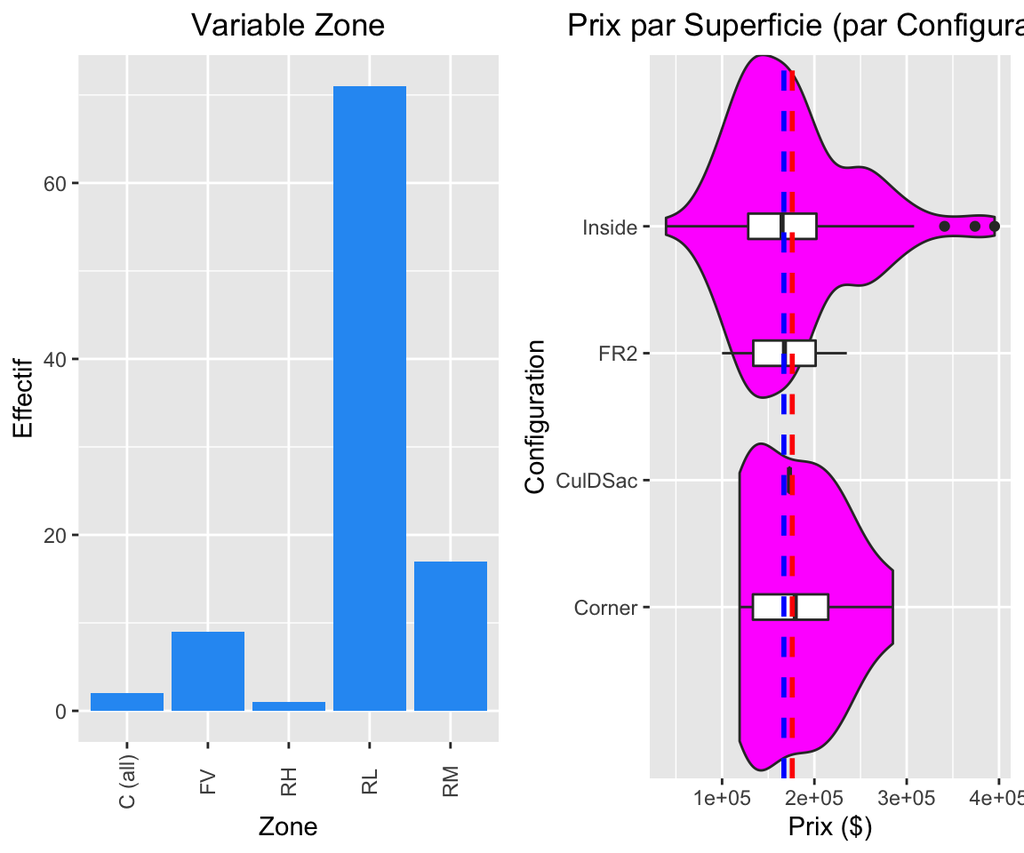

Graphiques à l’aide de `ggplot2`.

```r
g1 <- ggplot(database, aes(Zone)) + geom_bar(fill = "#2A9BF3") +
                              xlab("Zone") +
                              ylab("Effectif") +
                              labs(title = "Variable Zone") +
                              theme(axis.text.x = element_text(angle = 90, vjust = 0.5),
                              plot.title = element_text(hjust = 0.5))

g2 <- ggplot(database, aes(x = droplevels(Configuration), y = Prix)) + geom_violin(fill = "magenta", adjust = 1) +
                                                                 coord_flip() +
                                                                 geom_boxplot(width = 0.2) +
                                                                 geom_hline(aes(yintercept = mean(Prix)), color = "red", linetype = "dashed", size = 1, show.legend = TRUE) +
                                                                 geom_hline(aes(yintercept = median(Prix)), color = "blue", linetype = "dashed", size = 1) +
                                                                 xlab("Configuration") +
                                                                 ylab("Prix ($)") +
                                                                 ggtitle("Prix par Superficie (par Configuration)") +
                                                                 theme(plot.title = element_text(hjust = 0.5))
grid.arrange(g1, g2, ncol = 2)
```

À l’entête d’un *chunk* R, il y a plusieurs options possibles:

- `fig.align` permet d’alligner un graphique (soit `"left"`, `"right"` ou `"center"`).
- `fig.cap` permet d’ajouter un sous-titre à un graphique.
- `fig.height`, `fig.width` permettent de modifier la hauteur et la largeur respectivement.
- `fig.keep` permet de déterminer quels graphiques à l’intérieur du *chunk* seront conservés au fichier final.
- `fig.show` permet de déterminer ou le graphiques apparaissent dans le fichier final (e.g. à l’endroit où ils sont inscrits dans le code ou à la fin du *chunk*)
- etc.